# Experiment7_AllCode

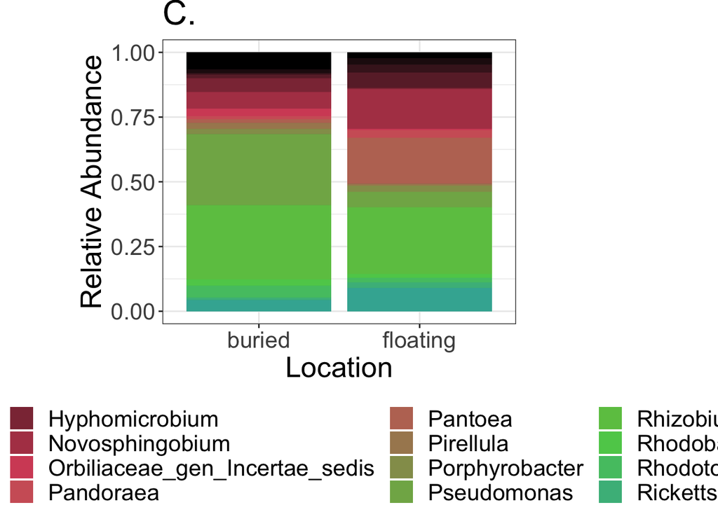

```r
genera <- pivot.genus$genus

genus <- counts_wtax %>% dplyr::select(NuBotR1:genus) %>% pivot_longer(cols = c(NuBotR1:NyTopR3), names_to = "SampleID", values_to = "value") %>% group_by(SampleID, class, genus) %>% filter(genus %in% genera)
genus.md <- merge(genus, metadata, by = "SampleID")

genus.plot <- ggplot(genus.md, aes(fill = genus, y = value, x = Location)) + geom_bar(position = "fill", stat = "identity") + theme(legend.position = "right") + labs(y = "Relative Abundance", title = "C.")  +
  theme(axis.text.x = element_text(
    angle = 90,
    vjust = .5,
    hjust = 1
  )) + theme_bw() + scale_fill_manual(values = largepal)+ theme(text=element_text(size=20), legend.position = "bottom", legend.direction = "horizontal", plot.margin=unit(c(0,5,0,2), 'cm'))

genus.plot
```

Which ASVs are more enriched in the top/bottom treatments (DeSEQ)

```r
# Create a new `phyloseq` object that has the absolute abundance
counts_wtax2 <- fread("/Users/briannepalmer/Library/CloudStorage/OneDrive-Personal/LeafFossilization/Dataframes_to_merge/merged_edited.csv")

counts_wtax2$n <- rowSums(counts_wtax2[ , c(2:13)], na.rm=TRUE)
x <- seq(1:8786)
otu.names <- as.vector(paste0("ASV", x))
counts_wtax2$otu <- otu.names

otu.table2 <- counts_wtax2[,c(23, 2:13)]
otu.table2 <- otu.table2[,-1]
otu.table2 <- as.matrix(otu.table2)
rownames(otu.table2) <- counts_wtax2$otu

tax.table2 <- counts_wtax2[,c(23,14:20)]
tax.table2 <- as.matrix(tax.table2)
rownames(tax.table2) <- counts_wtax2$otu
tax.table2 <- tax.table2[,-1]

otu.table2 <- otu_table(otu.table2, taxa_are_rows = TRUE)
tax.table2 <- tax_table(tax.table2)
sam.data <- as.matrix(metadata)
sam.data <- sample_data(metadata)
rownames(sam.data) <- metadata$SampleID

ps2 <- phyloseq(otu.table2, tax.table2, sam.data)
ps2 <- subset_taxa(ps2, kingdom !="Unassigned")
ps2 <- subset_taxa(ps2, phylum != "NA")

mb = subset_samples(ps2) %>%
                      filter_taxa(function(x) sum(x) > 0, TRUE)

# Next, we need to check the order of our Site levels. DESeq2 takes the first level as the 'Control' and the second level as the 'Treatment', and this is needed for downstream interpretation of results.
head(sample_data(mb)$Location)
```

```
## [1] "buried"   "buried"   "buried"   "floating" "floating" "floating"
```

```r
# Now we can prepare the DESeq2 object and run our analysis.

# First, we will convert the sequence count data from our phyloseq object into the proper format for DESeq2
mb.dds <- phyloseq_to_deseq2(mb, ~ Location)
# Next we need to estimate the size factors for our sequences
gm_mean = function(x, na.rm=TRUE){
    exp(sum(log(x[x > 0]), na.rm=na.rm) / length(x))
}
geoMeans = apply(counts(mb.dds), 1, gm_mean)
mb.dds = estimateSizeFactors(mb.dds, geoMeans = geoMeans)

# Finally, we can run the core DESeq2 algorithm
mb.dds = DESeq(mb.dds, fitType="local")
# Create a new dataframe from the results of our DESeq2 run
mb.res = results(mb.dds)

# Reorder the sequences by their adjusted p-values
mb.res = mb.res[order(mb.res$padj, na.last=NA), ]

# Set your alpha for testing significance, and filter out non-significant results
alpha = 0.05
mb.sigtab = mb.res[(mb.res$padj < alpha), ]

mb.res = cbind(as(mb.res, "data.frame"), as(tax_table(mb)[rownames(mb.res), ], "matrix"))

# Add taxonomy information to each sequence
mb.sigtab = cbind(as(mb.sigtab, "data.frame"), as(tax_table(mb)[rownames(mb.sigtab), ], "matrix"))
head(mb.sigtab)
```

```
##         baseMean log2FoldChange    lfcSE      stat       pvalue         padj
## ASV351  66.95459      -24.00855 3.003511 -7.993496 1.311652e-15 2.071098e-12
## ASV114  53.15486       23.47716 3.003951  7.815429 5.477608e-15 3.542686e-12
## ASV272  59.63976      -23.28654 3.003552 -7.753002 8.974506e-15 3.542686e-12
## ASV5490 40.22563      -23.33534 3.003733 -7.768781 7.924474e-15 3.542686e-12
## ASV5334 36.27996      -23.19373 3.003793 -7.721480 1.149864e-14 3.631272e-12
## ASV367  20.19671      -22.39785 3.004284 -7.455304 8.966073e-14 2.051843e-11
##          kingdom           phylum               class            order
## ASV351  Bacteria   Proteobacteria Alphaproteobacteria Sphingomonadales
## ASV114  Bacteria Actinobacteriota      Actinobacteria    Micrococcales
## ASV272  Bacteria   Proteobacteria Alphaproteobacteria Sphingomonadales
## ASV5490 Bacteria  Planctomycetota      Planctomycetes     Pirellulales
## ASV5334 Bacteria  Planctomycetota      Planctomycetes     Pirellulales
## ASV367  Bacteria   Proteobacteria Alphaproteobacteria Sphingomonadales
##                    family        genus species
## ASV351  Sphingomonadaceae         <NA>    <NA>
## ASV114  Microbacteriaceae         <NA>    <NA>
## ASV272  Sphingomonadaceae Sphingopyxis    <NA>
## ASV5490     Pirellulaceae    Pirellula    <NA>
## ASV5334     Pirellulaceae    Pirellula    <NA>
## ASV367  Sphingomonadaceae Sphingopyxis    <NA>
```

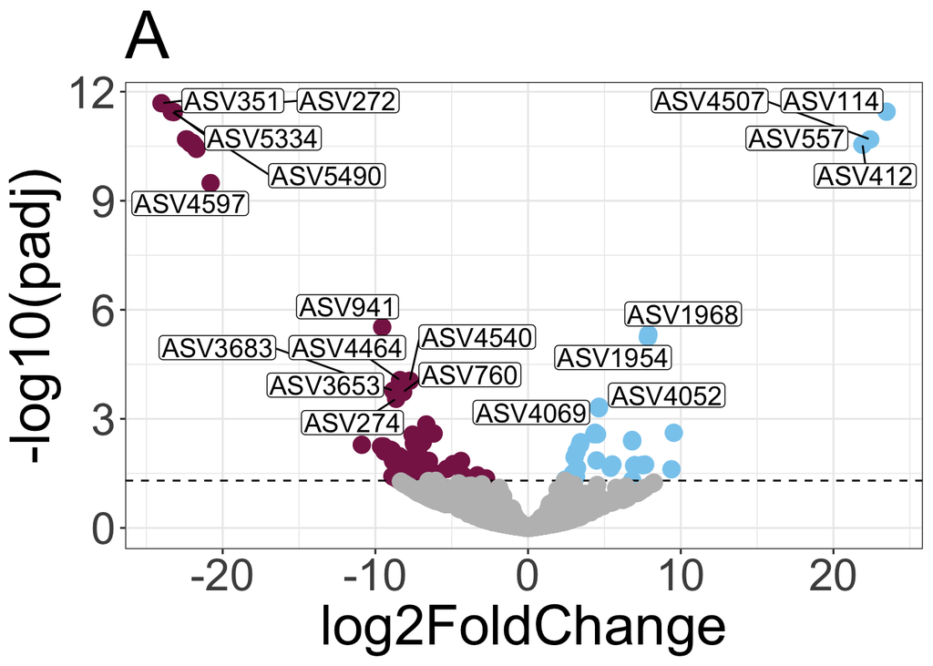

```r
# Rearrange the order of our OTUs by Phylum.
x = tapply(mb.sigtab$log2FoldChange, mb.sigtab$phylum, function(x) max(x))
x = sort(x, TRUE)
mb.sigtab$Phylum = factor(as.character(mb.sigtab$phylum), levels=names(x))


mb.sig.genus <- mb.sigtab %>% filter(genus != "uncultured", genus != "Mitochondria", genus != "Chloroplast")
mb.sig.genus$group<- ifelse(mb.sig.genus$log2FoldChange > 0, 'buried','floating')
mb.sig.genus$color <- ifelse(mb.sig.genus$log2FoldChange > 0, '#882255','#88CCEE')
mb.ns <- mb.res %>% filter(padj > 0.05)

mb.sigtab$group<- ifelse(mb.sigtab$log2FoldChange < 0, 'buried','floating')
mb.sigtab$color <- ifelse(mb.sigtab$log2FoldChange < 0, '#882255','#88CCEE')


volcano.plot <- ggplot(mb.sigtab, aes(x = log2FoldChange, y = -log10(padj))) + geom_point(color = mb.sigtab$color, size = 4) + geom_hline(aes(yintercept =-log10(0.05)), linetype = "dashed") + theme_bw() + ggtitle("A") + geom_point(data = mb.ns, mapping = aes(x = mb.ns$log2FoldChange, y = -log10(mb.ns$padj)), color = "gray", size = 4) + ggrepel::geom_label_repel(aes(label = rownames(mb.sigtab)), max.overlaps = 20, size = 5, label.padding = 0.1) + theme(text=element_text(size=30))

volcano.plot
```

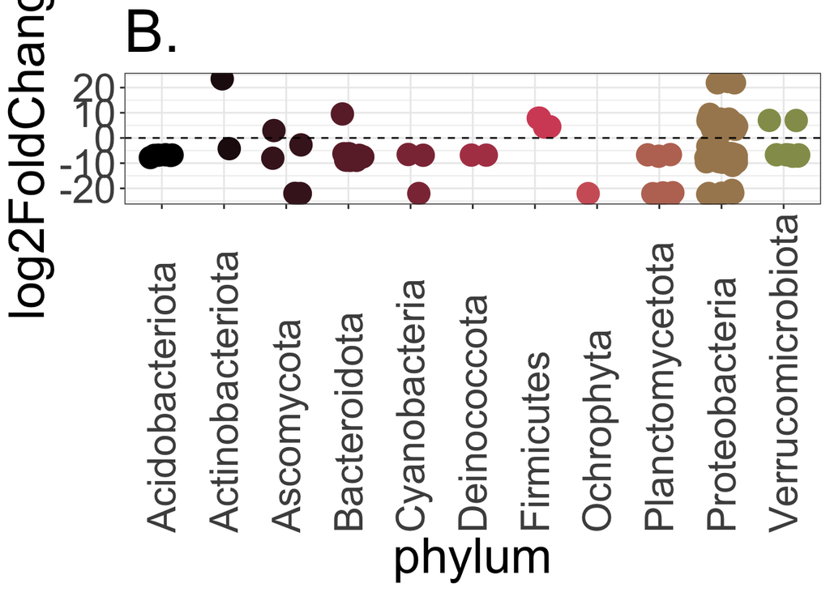

```r
# Create and display the plot
deseq.plot = ggplot(mb.sigtab, aes(x=phylum, y=log2FoldChange, color=phylum)) + geom_jitter(size=6, width=0.25) +
  scale_color_manual(values = largepal) + ggtitle("B.") + theme_bw() + theme(legend.position = "none") + theme(axis.text.x = element_text(angle = 90, hjust = 0, vjust=0.5)) + geom_hline(aes(yintercept = 0), linetype = "dashed")+ theme(text=element_text(size=30))

deseq.plot
```

Make Figure 3 for MS

```r
jpeg("figures/WaterLiliesTopBottom/Figure3_Jan16.jpeg", height = 1200, width = 2400)
volcano.plot+deseq.plot
dev.off()
```

diatoms only (phylya Gryista and ochrophyta)

```r
diatoms <- counts_wtax2 %>% filter(phylum %in% c("Gryista", "Ochrophyta")) %>% dplyr::select(NuBotR1:genus)
diatoms <- diatoms %>% dplyr::select(NuBotR1:genus) %>% pivot_longer(cols = c(NuBotR1:NyTopR3), names_to = "SampleID", values_to = "value")
diatoms <- merge(diatoms, metadata, by = "SampleID")
```

[figure not shown]

```r
library(ggbeeswarm)
diatom.plot <- ggplot(diatoms, aes(color = family, y = value, x = Location)) + geom_beeswarm(size = 3) + theme(legend.position = "right") + labs(y = "Absolute Abundance", title = "D.")  +
  theme(axis.text.x = element_text(
    angle = 90,
    vjust = .5,
    hjust = 1
  )) + theme_bw() + scale_fill_manual(values = pal)+ scale_color_manual(values = pal) + theme(text=element_text(size=20), legend.position = "none", legend.direction = "horizontal", plot.margin=unit(c(0,5,0,2), 'cm')) + facet_wrap(.~family, scales = "free", nrow = 1)

diatom.plot
```

make figure 2 (taxa Plots) –potentially add the diatom plot here

```r
jpeg("figures/WaterLiliesTopBottom/Figure2.jpeg", width = 2800, height = 2400)
(p.tax+e.tax+genus.plot)/diatom.plot
dev.off()
```

Now we can move onto the functions – for this I used Bugbase (phentype predictions) and PiCRUST2

Bugbase

```r
bugbase <- fread("/Users/briannepalmer/Library/CloudStorage/OneDrive-Personal/LeafFossilization/Leaf Fossilization Experiments_3_4_7_8/Experiment 7/BugBaseWaterLilies.csv")
```

```r
compare_means(Rel ~ Treatment, data = bugbase,
              group.by = "Function")
```

```
## # A tibble: 7 × 9
##   Function           .y.   group1 group2        p p.adj p.format p.signif method
##   <chr>              <chr> <chr>  <chr>     <dbl> <dbl> <chr>    <chr>    <chr>
## 1 Aerobic            Rel   Buried Floating 0.0260  0.18 0.026    *        Wilco…
## 2 Anaerobic          Rel   Buried Floating 0.0931  0.27 0.093    ns       Wilco…
## 3 FacultiveAnaerobic Rel   Buried Floating 0.158   0.27 0.158    ns       Wilco…
## 4 FormsBiofilm       Rel   Buried Floating 0.0411  0.21 0.041    *        Wilco…
## 5 GramNegative       Rel   Buried Floating 0.0898  0.27 0.090    ns       Wilco…
## 6 GramPositive       Rel   Buried Floating 0.0266  0.18 0.027    *        Wilco…
## 7 StressTolerant     Rel   Buried Floating 0.0411  0.21 0.041    *        Wilco…
```

[figure not shown]

```r
bugbase.plot <- bugbase %>% filter(Function != "GramPositive", Function != "GramNegative")

stat.test <- bugbase.plot %>%
  group_by(Function) %>%
  wilcox_test(Rel ~ Treatment) %>%
  adjust_pvalue(method = "bonferroni") %>%
  add_significance()
stat.test <- stat.test %>% add_xy_position(x = "Treatment")
```

Now, onto PiCRUST2

for more details see the file called “picrust_waterlilies.R” – this is where I parsed a lot of the data and stored it in the data folder

```r
p2_PW <- "/Users/briannepalmer/Downloads/picrust2-2.5.1/picrust2_out_stratified/pathways_out/path_abun_unstrat.tsv.gz" # pathways
p2_KO <- "/Users/briannepalmer/Downloads/picrust2-2.5.1/picrust2_out_stratified/KO_metagenome_out/pred_metagenome_unstrat.tsv.gz" # KEGG
p2_EC <-"/Users/briannepalmer/Downloads/picrust2-2.5.1/picrust2_out_stratified/EC_metagenome_out/pred_metagenome_unstrat.tsv.gz"
sam_tab <- "/Users/briannepalmer/Library/CloudStorage/OneDrive-Personal/LeafFossilization/NymphaeaNuphar_18S/sample-metadata.csv" # metadata
```

```r
# imports PiCRUST data as phyloseq object
ps.pw <- import_picrust2(
  p2_PW,
  sam_tab,
  trait = "PATHWAY")

random_tree = rtree(ntaxa(ps.pw), rooted=TRUE, tip.label=taxa_names(ps.pw))
ps.pw = merge_phyloseq(ps.pw,random_tree)
```

[output not shown]

```
## Also defined by 'tidytree'
```

[output not shown]

```
## Also defined by 'tidytree'
```

[output not shown]

```
## Also defined by 'tidytree'
```

[output not shown]

```
## Also defined by 'tidytree'
```

```r
ps.pw@sam_data <- sample_data(metadata)
rownames(ps@sam_data) <- ps@sam_data$SampleID
colnames(ps@otu_table) <- ps@sam_data$SampleID
```

[output not shown]

```
## Also defined by 'tidytree'
```

[output not shown]

```
## Also defined by 'tidytree'
```

[output not shown]

```
## Also defined by 'tidytree'
```

[output not shown]

```
## Also defined by 'tidytree'
```

[output not shown]

```
## Also defined by 'tidytree'
```

[output not shown]

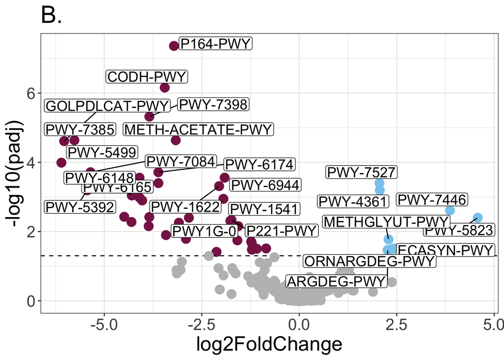

Ordnation

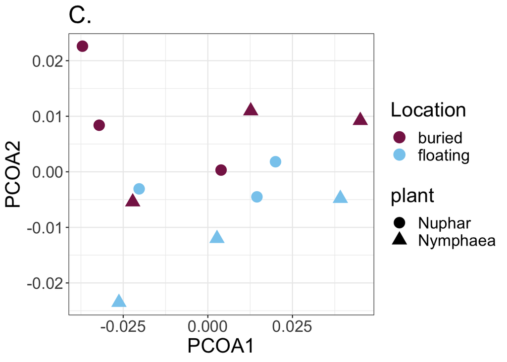

STATISTICS TIME! (PERMANOVA)

```r
set.seed(12345)
adonis2(phyloseq::distance(GP1, method="bray") ~ Location,
       data = metadata) # 0.352
```

```
## Permutation test for adonis under reduced model
## Terms added sequentially (first to last)
## Permutation: free
## Number of permutations: 999
##
## adonis2(formula = phyloseq::distance(GP1, method = "bray") ~ Location, data = metadata)
##          Df SumOfSqs      R2      F Pr(>F)
## Location  1 0.009028 0.08643 0.9461  0.352
## Residual 10 0.095419 0.91357
## Total    11 0.104446 1.00000
```

```r
adonis2(phyloseq::distance(GP1, method="bray") ~ plant,
        data = metadata) # 0.37
```

```
## Permutation test for adonis under reduced model
## Terms added sequentially (first to last)
## Permutation: free
## Number of permutations: 999
##
## adonis2(formula = phyloseq::distance(GP1, method = "bray") ~ plant, data = metadata)
##          Df SumOfSqs      R2      F Pr(>F)
## plant     1 0.009520 0.09115 1.0029   0.37
## Residual 10 0.094926 0.90885
## Total    11 0.104446 1.00000
```